# Beta diversity of insect visitors

B. Karina Montero

2024-05-02

### LOAD LIBRARIES

```r
rm(list = ls())

# basics
library(tidyverse)
library(stringr)
library(vegan)
library(magrittr)
library(ggplot2)
library(ggpubr)

# diversity
library(iNEXT)
library(hilldiv)

# rmd
library(details)
library(knitr)
library(kableExtra)
```

### WORKING DIRECTORIES

```r
source("/home/kari/Dropbox/PollenUCR/01_scripts/UCR_workingDirectories.R")
```

### LOAD DATA

```r
bichos_long_filter <- read.csv(paste0(dataDir,
    "/bichos_long_filter.csv"))
```

### GRAPHICAL PARAMETERS

```r
ord_theme <- theme_set(theme_bw(base_size = 13)) + theme( panel.grid.major = element_blank(), panel.grid.minor = element_blank(), panel.background = element_blank(), panel.border=element_rect(fill = NA, colour = "black"),plot.margin=grid::unit(c(5,5,5,5), "mm"), axis.text.x = element_text(colour = "black", size=rel(1)), axis.text.y=element_text(size=rel(1), colour="black"), axis.title = element_text(size = rel(1)))

season_order <- c("dry", "rainy")

season_col <- c("#FFC107", "#004D40")

season_color <- scale_color_manual(name = "Season",
                                   values = season_col,
                                   limits = season_order,
                                   labels = c("Dry", "Wet")
                                   #guide = "right"
                                   )
season_fill <- scale_fill_manual(name = "Season",
                                   values = season_col,
                                   limits = season_order,
                                   labels = c("Dry", "Wet")
                                   #guide = "none"
                                   )

project_order <- c("Cultivos", "Silvestres")

project_symbol <- c(21, 22)

project_line <- c(1, 2)

project_shape <- scale_shape_manual(name = "Sampling",
                                   values = project_symbol,
                                   limits = project_order,
                                   labels = c("Fruit crops", "Wild plants")
                                   #guide = "right"
                                   )


project_line <- scale_linetype_manual(name = "",
                                   values = project_line,
                                   limits = project_order,
                                   labels = c("Fruit crops", "Wild plants"),
                                   guide = "none"
                                   )


proj_season_order <- c("Cultivos_dry", "Cultivos_rainy", "Silvestres_dry", "Silvestres_rainy")

proj_season_col <- c("#FFC107",  "#004D40", "#FFC107", "#004D40")

proj_season_symbol <- c(15, 16, 17, 18)

proj_season_shape <- scale_shape_manual(name = "Sampling",
                                   values = proj_season_symbol,
                                   limits = proj_season_order,
                                   labels = c("Fruit crops / Dry", "Fruit crops / Wet", "Wild plants / Dry", "Wild plants / Wet")
                                   )

proj_season_color <- scale_color_manual(name = "Season",
                                   values = proj_season_col,
                                   limits = proj_season_order,
                                   labels = c("Fruit crops / Dry", "Fruit crops / Wet", "Wild plants / Dry", "Wild plants / Wet")
                                   #guide = "right"
                                   )

proj_season_fill <- scale_fill_manual(name = "Season",
                                   values = proj_season_col,
                                   limits = proj_season_order,
                                   labels = c("Fruit crops / Dry", "Fruit crops / Wet", "Wild plants / Dry", "Wild plants / Wet")
                                   #guide = "none"
                                   )


crop_transect_order <- c( "Malus domestica", "Persea americana","Prunus domestica","Rubus", "Suria", "Tajo")

crop_transect_col <- c("#D55E00", "#009E73", "#F0E442", "#0072B2", "Black", "Grey60")


crop_transect_color <- scale_color_manual(name = "Fruit crop / Transect",
                                   values = crop_transect_col,
                                   limits = crop_transect_order,
                                   labels = c( "Malus domestica", "Persea americana","Prunus domestica","Rubus sp.", "Wild plants (Suria)", "Wild plants (Tajo)")
                                   #guide = "right"
                                   )
crop_transect_fill <- scale_fill_manual(name = "Fruitcrop",
                                   values = crop_transect_col,
                                   limits = crop_transect_order,
                                   guide = "none"
                                   )
```

# BETA DIVERSITY

Pairwise distance based on Hill numbers

The Sørensen‐type overlap (CqN for diversity) quantifies the effective average proportion of a subsystem (sampling unit) visitors that is shared across all sampling units. This is thus a metric that quantifies overlap from the subsystem (sampling units’) perspective.

The Jaccard‐type overlap (UqN) quantifies the effective proportion of visitors in a system (crop/transect) that are shared across all subsystem (sampling units). Hence, this metric quantifies overlap from the perspective of the overall system (crop/transect).

The Sørensen‐type turnover‐complement (VqN) is the complement of the Sørensen‐type turnover, which quantifies the normalized visitor turnover rate with respect to the average subsystem (i.e., alpha), thus provides the proportion of a typical subsystem (sampling unit) that changes across subsystems.

The Jaccard‐type turnover‐complement (SqN) is the complement of the Jaccard‐type turnover, which quantifies the normalized visitor turnover rate with respect to the whole system (i.e. gamma).

Its corresponding dissimilarity eg. (1 − UqN) quantifies the effective proportion of nonshared visitors in the overall system.

Modified from: A guide to the application of Hill numbers to DNA‐based diversity analyses, Alberdi &Gilbert 2019 Mol Ecol Res

## Dissimilarity matrix project / season

Prepare data

```r
table(bichos_long_filter$Proj_season, bichos_long_filter$Fruitcrop_transect)
```

```
##
##                    Malus domestica Persea americana Prunus domestica Rubus
##   Cultivos_dry                 123              159              134     0
##   Cultivos_rainy               119             1910               21   270
##   Silvestres_dry                 0                0                0     0
##   Silvestres_rainy               0                0                0     0
##
##                    Suria Tajo
##   Cultivos_dry         0    0
##   Cultivos_rainy       0    0
##   Silvestres_dry     155  275
##   Silvestres_rainy   411  399
```

```r
# hierarchy
bichos_hier_df <- bichos_long_filter %>%
    group_by(Sampling_unit, Proj_season, Project,
        Season) %>%
    dplyr::slice(1) %>%
    select(Sampling_unit, Proj_season, Project,
        Season) %>%
    data.frame %>%
    mutate(Sampling_unit = gsub("\\ ", ".", Sampling_unit),
        Proj_season = gsub("\\ ", ".", Proj_season))

bichos_hier <- bichos_long_filter %>%
    group_by(Sampling_unit, Proj_season) %>%
    dplyr::slice(1) %>%
    select(Sampling_unit, Proj_season) %>%
    data.frame %>%
    mutate(Sampling_unit = gsub("\\ ", ".", Sampling_unit),
        Proj_season = gsub("\\ ", ".", Proj_season))
head(bichos_hier)
```

```
##                           Sampling_unit    Proj_season
## 1   Cultivos_10_Malus.domestica_January   Cultivos_dry
## 2  Cultivos_10_Persea.americana_January   Cultivos_dry
## 3  Cultivos_10_Prunus.domestica_January   Cultivos_dry
## 4 Cultivos_11_Persea.americana_February   Cultivos_dry
## 5                 Cultivos_15_Rubus_May Cultivos_rainy
## 6                Cultivos_17_Rubus_June Cultivos_rainy
```

```r
# format into a integer matrix
bichos_sampling <- bichos_long_filter %>%
    group_by(Sampling_unit, Lowest_assignment) %>%
    summarise(n_Lowest = n()) %>%
    data.frame

bichos_sampling$group <- paste(bichos_sampling$Proj_season,
    bichos_sampling$Sampling_unit, sep = ".")
head(bichos_sampling)
```

```
##                         Sampling_unit     Lowest_assignment n_Lowest
## 1 Cultivos_10_Malus domestica_January Allograpta neotropica        1
## 2 Cultivos_10_Malus domestica_January        Apis mellifera       72
## 3 Cultivos_10_Malus domestica_January     Argentinomyia sp1        1
## 4 Cultivos_10_Malus domestica_January    Astylus indentatus       16
## 5 Cultivos_10_Malus domestica_January         Conotelus sp1        1
## 6 Cultivos_10_Malus domestica_January  Family_Chrysomelidae        1
##                                  group
## 1 .Cultivos_10_Malus domestica_January
## 2 .Cultivos_10_Malus domestica_January
## 3 .Cultivos_10_Malus domestica_January
## 4 .Cultivos_10_Malus domestica_January
## 5 .Cultivos_10_Malus domestica_January
## 6 .Cultivos_10_Malus domestica_January
```

```r
# Incidence matrix

bichos_sampling <- bichos_long_filter %>%
    group_by(Sampling_unit, Lowest_assignment) %>%
    summarise(n_Lowest = n()) %>%
    mutate(n_Lowest = as.integer(ifelse(n_Lowest >
        0, 1, 0)))

# matrix
incidence_sampling <- bichos_sampling %>%
    spread(Sampling_unit, n_Lowest, fill = 0) %>%
    data.frame

rownames(incidence_sampling) <- incidence_sampling[,
    1]

incidence_sampling <- incidence_sampling %>%
    select(-Lowest_assignment)
```

### Distance matrix (incidence data)

```r
head(bichos_hier)
```

```
##                           Sampling_unit    Proj_season
## 1   Cultivos_10_Malus.domestica_January   Cultivos_dry
## 2  Cultivos_10_Persea.americana_January   Cultivos_dry
## 3  Cultivos_10_Prunus.domestica_January   Cultivos_dry
## 4 Cultivos_11_Persea.americana_February   Cultivos_dry
## 5                 Cultivos_15_Rubus_May Cultivos_rainy
## 6                Cultivos_17_Rubus_June Cultivos_rainy
```

```r
dist_q0 <- pair_dis(incidence_sampling, qvalue = 0)
dist_q1 <- pair_dis(incidence_sampling, qvalue = 1)
dist_q2 <- pair_dis(incidence_sampling, qvalue = 2)

sorensen_dist_q0 <- as.dist(dist_q0$L1_CqN)
sorensen_dist_q1 <- as.dist(dist_q1$L1_CqN)
sorensen_dist_q2 <- as.dist(dist_q2$L1_CqN)

# write.csv(sorensen_dist_q0,
# paste0(dataDir,
# '/Sorensen_Hill_distance.csv'))
```

Test whether the the grouping factor (Cultivos_dry vs. Cultivos_rainy vs. Silvestres_dry vs. Silvestres_rainy) has a significant effect on overall insect visitor composition based on incidence data.

```r
set.seed(10112023)
incidence_permanova_q0 <- adonis2(t(sorensen_dist_q0) ~
    Season + Project, data = bichos_hier_df, permutations = 9999,
    na.rm = TRUE, by = "margin")

incidence_permanova_q0
```

```
## Permutation test for adonis under reduced model
## Marginal effects of terms
## Permutation: free
## Number of permutations: 9999
##
## adonis2(formula = t(sorensen_dist_q0) ~ Season + Project, data = bichos_hier_df, permutations = 9999, by = "margin", na.rm = TRUE)
##          Df SumOfSqs      R2      F Pr(>F)
## Season    1   0.6643 0.03557 2.2960 0.0053 **
## Project   1   2.0780 0.11128 7.1826 0.0001 ***
## Residual 54  15.6227 0.83663
## Total    56  18.6735 1.00000
## ---
## Signif. codes:  0 '***' 0.001 '**' 0.01 '*' 0.05 '.' 0.1 ' ' 1
```

```r
incidence_permanova_q1 <- adonis2(t(sorensen_dist_q1) ~
    Project + Season, data = bichos_hier_df, permutations = 9999,
    na.rm = TRUE, by = "margin")
incidence_permanova_q1
```

```
## Permutation test for adonis under reduced model
## Marginal effects of terms
## Permutation: free
## Number of permutations: 9999
##
## adonis2(formula = t(sorensen_dist_q1) ~ Project + Season, data = bichos_hier_df, permutations = 9999, by = "margin", na.rm = TRUE)
##          Df SumOfSqs      R2      F Pr(>F)
## Project   1   2.0850 0.11414 7.4128  1e-04 ***
## Season    1   0.6832 0.03740 2.4289  3e-03 **
## Residual 54  15.1886 0.83145
## Total    56  18.2676 1.00000
## ---
## Signif. codes:  0 '***' 0.001 '**' 0.01 '*' 0.05 '.' 0.1 ' ' 1
```

```r
incidence_permanova_q2 <- adonis2(t(sorensen_dist_q2) ~
    Project + Season, data = bichos_hier_df, permutations = 9999,
    na.rm = TRUE, by = "margin")
incidence_permanova_q2
```

```
## Permutation test for adonis under reduced model
## Marginal effects of terms
## Permutation: free
## Number of permutations: 9999
##
## adonis2(formula = t(sorensen_dist_q2) ~ Project + Season, data = bichos_hier_df, permutations = 9999, by = "margin", na.rm = TRUE)
##          Df SumOfSqs      R2      F Pr(>F)
## Project   1   2.0780 0.11128 7.1826 0.0001 ***
## Season    1   0.6643 0.03557 2.2960 0.0054 **
## Residual 54  15.6227 0.83663
## Total    56  18.6735 1.00000
## ---
## Signif. codes:  0 '***' 0.001 '**' 0.01 '*' 0.05 '.' 0.1 ' ' 1
```

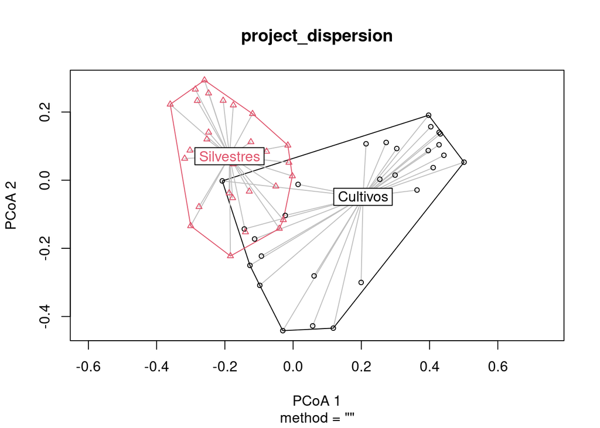

```r
# Calculate multivariate dispersions
project_dispersion <- betadisper(t(sorensen_dist_q1),
    bichos_hier_df$Project)
season_dispersion <- betadisper(t(sorensen_dist_q1),
    bichos_hier_df$Season)

plot(project_dispersion)
```

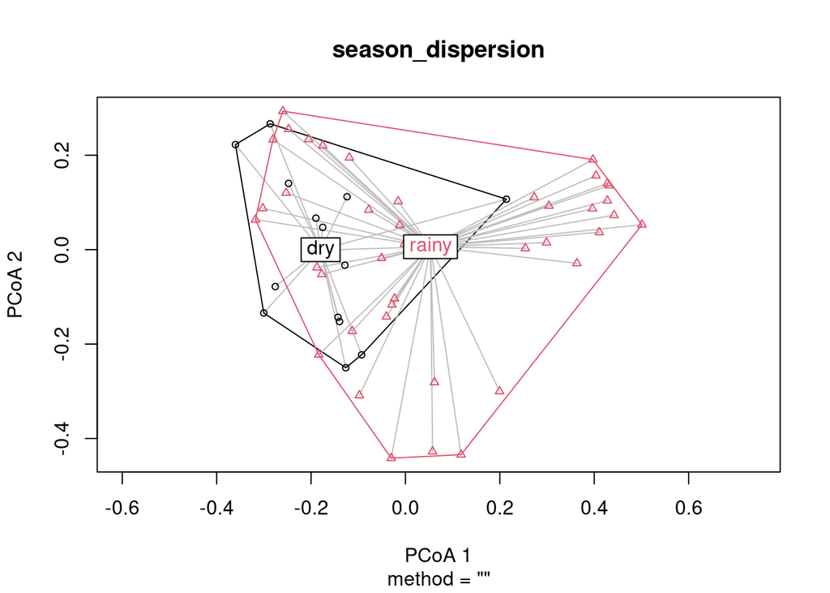

```r
plot(season_dispersion)
```

```r
# test for differences in dispersion
anova(project_dispersion)
```

```
## Analysis of Variance Table
##
## Response: Distances
##           Df   Sum Sq  Mean Sq F value   Pr(>F)
## Groups     1 0.044354 0.044354  9.7673 0.002835 **
## Residuals 55 0.249761 0.004541
## ---
## Signif. codes:  0 '***' 0.001 '**' 0.01 '*' 0.05 '.' 0.1 ' ' 1
```

```r
anova(season_dispersion)
```

```
## Analysis of Variance Table
##
## Response: Distances
##           Df   Sum Sq  Mean Sq F value    Pr(>F)
## Groups     1 0.034314 0.034314  14.081 0.0004234 ***
## Residuals 55 0.134027 0.002437
## ---
## Signif. codes:  0 '***' 0.001 '**' 0.01 '*' 0.05 '.' 0.1 ' ' 1
```

```r
# Permutation test for F
permutest(project_dispersion, pairwise = TRUE,
    permutations = 99)
```

```
##
## Permutation test for homogeneity of multivariate dispersions
## Permutation: free
## Number of permutations: 99
##
## Response: Distances
##           Df   Sum Sq  Mean Sq      F N.Perm Pr(>F)
## Groups     1 0.044354 0.044354 9.7673     99   0.01 **
## Residuals 55 0.249761 0.004541
## ---
## Signif. codes:  0 '***' 0.001 '**' 0.01 '*' 0.05 '.' 0.1 ' ' 1
##
## Pairwise comparisons:
## (Observed p-value below diagonal, permuted p-value above diagonal)
##             Cultivos Silvestres
## Cultivos                   0.01
## Silvestres 0.0028354
```

```r
permutest(season_dispersion, pairwise = TRUE,
    permutations = 99)
```

```
##
## Permutation test for homogeneity of multivariate dispersions
## Permutation: free
## Number of permutations: 99
##
## Response: Distances
##           Df   Sum Sq  Mean Sq      F N.Perm Pr(>F)
## Groups     1 0.034314 0.034314 14.081     99   0.01 **
## Residuals 55 0.134027 0.002437
## ---
## Signif. codes:  0 '***' 0.001 '**' 0.01 '*' 0.05 '.' 0.1 ' ' 1
##
## Pairwise comparisons:
## (Observed p-value below diagonal, permuted p-value above diagonal)
##              dry rainy
## dry               0.01
## rainy 0.00042343
```

```r
## Tukey's Honest Significant Differences
(proj_HSD <- TukeyHSD(project_dispersion))
```

```
##   Tukey multiple comparisons of means
##     95% family-wise confidence level
##
## Fit: aov(formula = distances ~ group, data = df)
##
## $group
##                            diff         lwr         upr     p adj
## Silvestres-Cultivos -0.05579908 -0.09157968 -0.02001847 0.0028354
```

```r
(season_HSD <- TukeyHSD(season_dispersion))
```

```
##   Tukey multiple comparisons of means
##     95% family-wise confidence level
##
## Fit: aov(formula = distances ~ group, data = df)
##
## $group
##                 diff        lwr        upr     p adj
## rainy-dry 0.05699981 0.02655858 0.08744103 0.0004234
```

> Perform a NMDS

```r
# run NMDS q0
set.seed(20102023)
values_NMDS_q0 <- metaMDS(as.dist(sorensen_dist_q0),
    k = 4, trymax = 500)
```

```
## *** Best solution repeated 4 times
```

```r
values_NMDS_q0$stress
```

```
## [1] 0.1206653
```

```r
stressplot(values_NMDS_q0)
```

[output not shown]

```r
# run NMDS q1
set.seed(20102023)
values_NMDS_q1 <- metaMDS(as.dist(sorensen_dist_q1),
    k = 4, trymax = 500)
```

```
## *** Best solution repeated 1 times
```

```r
values_NMDS_q1$stress
```

```
## [1] 0.1259136
```

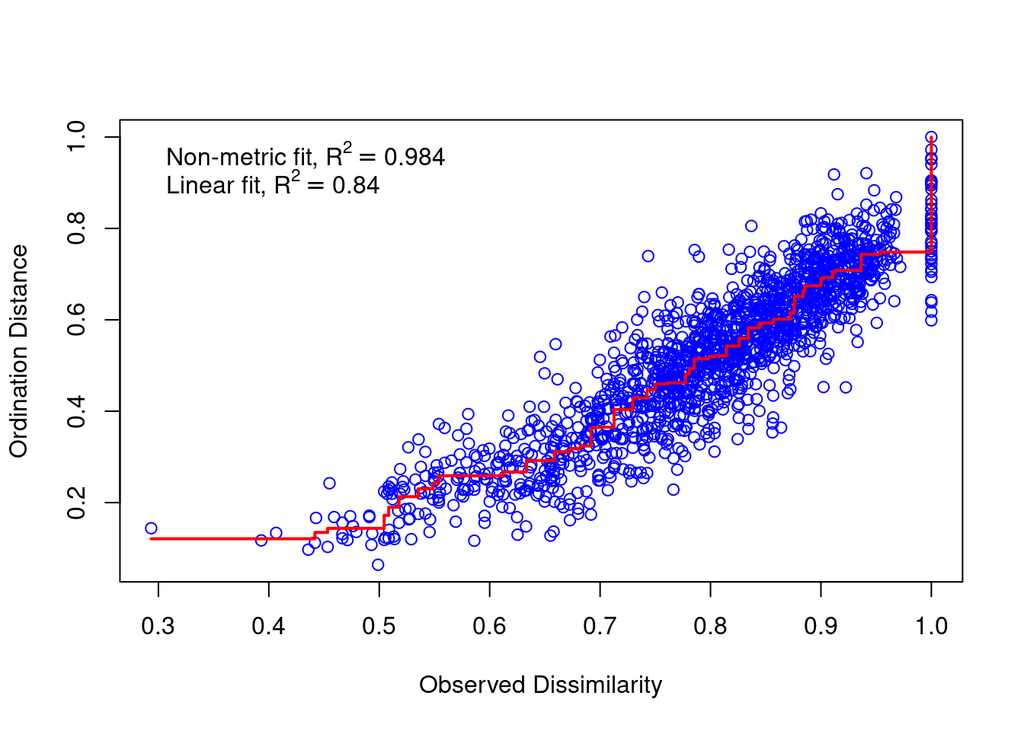

```r
stressplot(values_NMDS_q1)
```

```r
# run NMDS q2
set.seed(20102023)
values_NMDS_q2 <- metaMDS(as.dist(sorensen_dist_q2),
    k = 4, trymax = 500)
```

```
## *** Best solution repeated 4 times
```

```r
values_NMDS_q2$stress
```

```
## [1] 0.1206653
```

```r
stressplot(values_NMDS_q2)
```

[output not shown]

Get NMDS values for plot

```r
NMDS_scores_q0 <- data.frame(NMDS1 = values_NMDS_q0$point[,
    1], NMDS2 = values_NMDS_q0$point[, 2], NMDS3 = values_NMDS_q0$point[,
    3], NMDS4 = values_NMDS_q0$point[, 4], Group = as.factor(bichos_hier[,
    2]))
NMDS_centroids_q0 = aggregate(NMDS_scores_q0[,
    c(1:2)], by = list(NMDS_scores_q0[, 5]), FUN = mean)

NMDS_scores_q0$Sample <- rownames(NMDS_scores_q0)

colnames(NMDS_centroids_q0) <- c("Group", "x_cen",
    "y_cen")

NMDS_scores_q0 <- merge(NMDS_scores_q0, NMDS_centroids_q0,
    by = "Group")

NMDS_scores_q0 <- NMDS_scores_q0 %>%
    separate_wider_delim(Group, "_", names = c("Project",
        "Season"))

NMDS_scores_q0$Group <- paste(NMDS_scores_q0$Project,
    NMDS_scores_q0$Season, sep = "_")

NMDS_scores_q1 <- data.frame(NMDS1 = values_NMDS_q1$point[,
    1], NMDS2 = values_NMDS_q1$point[, 2], NMDS3 = values_NMDS_q1$point[,
    3], NMDS4 = values_NMDS_q1$point[, 4], Group = as.factor(bichos_hier[,
    2]))
NMDS_centroids_q1 = aggregate(NMDS_scores_q1[,
    c(1:2)], by = list(NMDS_scores_q1[, 5]), FUN = mean)

NMDS_scores_q1$Sample <- rownames(NMDS_scores_q1)

colnames(NMDS_centroids_q1) <- c("Group", "x_cen",
    "y_cen")

NMDS_scores_q1 <- merge(NMDS_scores_q1, NMDS_centroids_q1,
    by = "Group")

NMDS_scores_q1 <- NMDS_scores_q1 %>%
    separate_wider_delim(Group, "_", names = c("Project",
        "Season"))

NMDS_scores_q1$Group <- paste(NMDS_scores_q1$Project,
    NMDS_scores_q1$Season, sep = "_")

NMDS_scores_q2 <- data.frame(NMDS1 = values_NMDS_q2$point[,
    1], NMDS2 = values_NMDS_q2$point[, 2], NMDS3 = values_NMDS_q2$point[,
    3], NMDS4 = values_NMDS_q2$point[, 4], Group = as.factor(bichos_hier[,
    2]))

NMDS_centroids_q2 = aggregate(NMDS_scores_q2[,
    c(1:2)], by = list(NMDS_scores_q2[, 5]), FUN = mean)

NMDS_scores_q2$Sample <- rownames(NMDS_scores_q2)

colnames(NMDS_centroids_q2) <- c("Group", "x_cen",
    "y_cen")

NMDS_scores_q2 <- merge(NMDS_scores_q2, NMDS_centroids_q2,
    by = "Group")

NMDS_scores_q2 <- NMDS_scores_q2 %>%
    separate_wider_delim(Group, "_", names = c("Project",
        "Season"))
NMDS_scores_q2$Group <- paste(NMDS_scores_q2$Project,
    NMDS_scores_q2$Season, sep = "_")
```

Plot NMDS

```r
nmds_q0_proj_plot <- ggplot(NMDS_scores_q0, aes(x = NMDS1,
    y = NMDS2, colour = Season, fill = Season,
    shape = Project, linetype = Project)) + geom_point(size = 2) +
    season_color + season_fill + project_shape +
    project_line + geom_point(data = NMDS_scores_q0,
    aes(x = x_cen, y = y_cen, fill = Season, shape = Project),
    colour = "black", size = 5, show.legend = FALSE) +
    ord_theme + theme(legend.text = element_text(face = "italic",
    size = 10), legend.title = element_text(size = 12))

nmds_q1_proj_plot <- ggplot(NMDS_scores_q1, aes(x = NMDS1,
    y = NMDS2, colour = Season, fill = Season,
    shape = Project, linetype = Project)) + geom_point(size = 2) +
    season_color + season_fill + project_shape +
    project_line + geom_point(data = NMDS_scores_q1,
    aes(x = x_cen, y = y_cen, fill = Season, shape = Project),
    colour = "black", size = 5, show.legend = FALSE) +
    ord_theme + theme(legend.text = element_text(face = "italic",
    size = 10), legend.title = element_text(size = 12))

nmds_q2_proj_plot <- ggplot(NMDS_scores_q2, aes(x = NMDS1,
    y = NMDS2, colour = Season, fill = Season,
    shape = Project, linetype = Project)) + geom_point(size = 2) +
    season_color + season_fill + project_shape +
    project_line + geom_point(data = NMDS_scores_q2,
    aes(x = x_cen, y = y_cen, fill = Season, shape = Project),
    colour = "black", size = 5, show.legend = FALSE) +
    ord_theme + theme(legend.text = element_text(face = "italic",
    size = 10), legend.title = element_text(size = 12))


# function for ellipsess
veganCovEllipse <- function(cov, center = c(0,
    0), scale = 1, npoints = 100) {
    theta <- (0:npoints) * 2 * pi/npoints
    Circle <- cbind(cos(theta), sin(theta))
    t(center + scale * t(Circle %*% chol(cov)))
}

# ellipses for q0 plot

df_ell_q0 <- data.frame()  #sets up a data frame before running the function.
for (g in levels(as.factor(NMDS_scores_q0$Group))) {
    df_ell_q0 <- rbind(df_ell_q0, cbind(as.data.frame(with(NMDS_scores_q0[NMDS_scores_q0$Group ==
        g, ], veganCovEllipse(cov.wt(cbind(NMDS1,
        NMDS2), wt = rep(1/length(NMDS1), length(NMDS1)))$cov,
        center = c(mean(NMDS1), mean(NMDS2))))),
        Group = g))
}

df_ell_q0 <- df_ell_q0 %>%
    separate_wider_delim(Group, "_", names = c("Project",
        "Season"))
df_ell_q0$Group <- paste(df_ell_q0$Project, df_ell_q0$Season,
    sep = "_")

# data for labelling the ellipse
NMDS_mean_q0 = aggregate(NMDS_scores_q0[, c("NMDS1",
    "NMDS2")], list(group = NMDS_scores_q0$Group),
    mean)

NMDS_mean_q0 <- NMDS_mean_q0 %>%
    separate_wider_delim(group, "_", names = c("Project",
        "Season"))
NMDS_mean_q0$Group <- paste(NMDS_mean_q0$Project,
    NMDS_mean_q0$Season, sep = "_")

# ellipses for q1 plot

df_ell_q1 <- data.frame()  #sets up a data frame before running the function.
for (g in levels(as.factor(NMDS_scores_q1$Group))) {
    df_ell_q1 <- rbind(df_ell_q1, cbind(as.data.frame(with(NMDS_scores_q1[NMDS_scores_q1$Group ==
        g, ], veganCovEllipse(cov.wt(cbind(NMDS1,
        NMDS2), wt = rep(1/length(NMDS1), length(NMDS1)))$cov,
        center = c(mean(NMDS1), mean(NMDS2))))),
        Group = g))
}


df_ell_q1 <- df_ell_q1 %>%
    separate_wider_delim(Group, "_", names = c("Project",
        "Season"))
df_ell_q1$Group <- paste(df_ell_q1$Project, df_ell_q1$Season,
    sep = "_")

# data for labelling the ellipse
NMDS_mean_q1 = aggregate(NMDS_scores_q1[, c("NMDS1",
    "NMDS2")], list(group = NMDS_scores_q1$Group),
    mean)

NMDS_mean_q1 <- NMDS_mean_q1 %>%
    separate_wider_delim(group, "_", names = c("Project",
        "Season"))
NMDS_mean_q1$Group <- paste(NMDS_mean_q1$Project,
    NMDS_mean_q1$Season, sep = "_")


# ellipses for q2 plot

df_ell_q2 <- data.frame()  #sets up a data frame before running the function.
for (g in levels(as.factor(NMDS_scores_q2$Group))) {
    df_ell_q2 <- rbind(df_ell_q2, cbind(as.data.frame(with(NMDS_scores_q2[NMDS_scores_q2$Group ==
        g, ], veganCovEllipse(cov.wt(cbind(NMDS1,
        NMDS2), wt = rep(1/length(NMDS1), length(NMDS1)))$cov,
        center = c(mean(NMDS1), mean(NMDS2))))),
        Group = g))
}

df_ell_q2 <- df_ell_q2 %>%
    separate_wider_delim(Group, "_", names = c("Project",
        "Season"))
df_ell_q2$Group <- paste(df_ell_q2$Project, df_ell_q2$Season,
    sep = "_")

# data for labelling the ellipse
NMDS_mean_q2 = aggregate(NMDS_scores_q2[, c("NMDS1",
    "NMDS2")], list(group = NMDS_scores_q2$Group),
    mean)

NMDS_mean_q2 <- NMDS_mean_q2 %>%
    separate_wider_delim(group, "_", names = c("Project",
        "Season"))
NMDS_mean_q2$Group <- paste(NMDS_mean_q2$Project,
    NMDS_mean_q2$Season, sep = "_")


nmds_q0_proj_plot <- nmds_q0_proj_plot + geom_path(data = df_ell_q0,
    aes(x = NMDS1, y = NMDS2, group = Group))

nmds_q1_proj_plot <- nmds_q1_proj_plot + geom_path(data = df_ell_q1,
    aes(x = NMDS1, y = NMDS2, group = Group))

nmds_q2_proj_plot <- nmds_q2_proj_plot + geom_path(data = df_ell_q2,
    aes(x = NMDS1, y = NMDS2, group = Group))

NMDS_proj_season <- ggarrange(nmds_q0_proj_plot,
    nmds_q1_proj_plot, nmds_q2_proj_plot, nrow = 1,
    labels = c("a.", "b.", "c."), font.label = c(size = 16),
    common.legend = TRUE, legend = "bottom")

png(paste0(outputDir, "/Figures/NMDS_proj_season.png"),
    width = 3000, height = 1500, res = 300)
NMDS_proj_season
dev.off()
```

## Dissimilarity matrix fruitcrop_transect

Prepare data

```r
str(bichos_long_filter)
```

```
## 'data.frame':    3976 obs. of  26 variables:
##  $ X                   : int  1 2 3 4 5 6 7 8 9 10 ...
##  $ Row.names           : chr  "C_1" "C_10" "C_100" "C_1000" ...
##  $ Project             : chr  "Cultivos" "Cultivos" "Cultivos" "Cultivos" ...
##  $ Sampling_session    : chr  "5_1" "5_1" "5_1" "10" ...
##  $ Sampling_unit       : chr  "Cultivos_5_1_Persea americana_September" "Cultivos_5_1_Persea americana_September" "Cultivos_5_1_Persea americana_September" "Cultivos_10_Prunus domestica_January" ...
##  $ Day                 : int  9 9 9 19 19 19 19 19 19 19 ...
##  $ Month               : chr  "September" "September" "September" "January" ...
##  $ Year                : int  2021 2021 2021 2022 2022 2022 2022 2022 2022 2022 ...
##  $ Season              : chr  "rainy" "rainy" "rainy" "dry" ...
##  $ Proj_site           : chr  "Cultivos_Persea americana" "Cultivos_Persea americana" "Cultivos_Persea americana" "Cultivos_Prunus domestica" ...
##  $ Proj_season         : chr  "Cultivos_rainy" "Cultivos_rainy" "Cultivos_rainy" "Cultivos_dry" ...
##  $ Farm_transect       : chr  "Lauraceas" "Lauraceas" "Lauraceas" "Lauraceas" ...
##  $ Fruitcrop_transect  : chr  "Persea americana" "Persea americana" "Persea americana" "Prunus domestica" ...
##  $ Plant_species       : chr  "Persea americana" "Persea americana" "Persea americana" "Prunus domestica" ...
##  $ Order               : chr  "Hymenoptera" "Hymenoptera" "Diptera" "Hymenoptera" ...
##  $ Family              : chr  "Tiphiidae" "Tiphiidae" "Sciaridae" "Halictidae" ...
##  $ Genus               : chr  "Tiphia" "Tiphia" "Family_Sciaridae" "Lasioglossum" ...
##  $ Lowest_assignment   : chr  "Tiphia sp2" "Tiphia sp1" "Family_Sciaridae" "Lasioglossum sp2" ...
##  $ count_lowest        : int  81 81 81 25 25 25 25 25 25 25 ...
##  $ n_visitors          : int  242 242 242 140 140 140 140 140 140 140 ...
##  $ n_plants            : int  12 12 12 23 23 23 23 23 23 23 ...
##  $ giras_to_merge      : int  1 1 1 1 1 1 1 1 1 1 ...
##  $ Sampling_hours      : num  6 6 6 6 6 6 6 6 6 6 ...
##  $ Sampling_hours_total: num  6 6 6 6.5 6.5 6.5 6.5 6.5 6.5 6.5 ...
##  $ Plant_Family        : chr  NA NA NA NA ...
##  $ Fruitcrop_ruderal   : chr  NA NA NA NA ...
```

```r
# hierarchy
bichos_hier_df <- bichos_long_filter %>%
    group_by(Sampling_unit, Project, Season, Fruitcrop_transect) %>%
    slice(1) %>%
    select(Sampling_unit, Fruitcrop_transect) %>%
    data.frame %>%
    mutate(Sampling_unit = gsub("\\ ", ".", Sampling_unit),
        Fruitcrop_transect = gsub("\\ ", ".",
            Fruitcrop_transect))

# Incidence matrix

bichos_sampling <- bichos_long_filter %>%
    group_by(Sampling_unit, Lowest_assignment) %>%
    summarise(n_Lowest = n()) %>%
    mutate(n_Lowest = as.integer(ifelse(n_Lowest >
        0, 1, 0)))

head(bichos_sampling)
```

```
## # A tibble: 6 × 3
## # Groups:   Sampling_unit [1]
##   Sampling_unit                       Lowest_assignment     n_Lowest
##   <chr>                               <chr>                    <int>
## 1 Cultivos_10_Malus domestica_January Allograpta neotropica        1
## 2 Cultivos_10_Malus domestica_January Apis mellifera               1
## 3 Cultivos_10_Malus domestica_January Argentinomyia sp1            1
## 4 Cultivos_10_Malus domestica_January Astylus indentatus           1
## 5 Cultivos_10_Malus domestica_January Conotelus sp1                1
## 6 Cultivos_10_Malus domestica_January Family_Chrysomelidae         1
```

```r
# matrix
incidence_sampling <- bichos_sampling %>%
    spread(Sampling_unit, n_Lowest, fill = 0) %>%
    data.frame

rownames(incidence_sampling) <- incidence_sampling[,
    1]

incidence_sampling <- incidence_sampling %>%
    select(-Lowest_assignment)
```

### Distance matrix (incidence data)

```r
dist_q0 <- pair_dis(incidence_sampling, qvalue = 0)
dist_q1 <- pair_dis(incidence_sampling, qvalue = 1)
dist_q2 <- pair_dis(incidence_sampling, qvalue = 2)

sorensen_dist_q0 <- as.dist(dist_q0$L1_CqN)
sorensen_dist_q1 <- as.dist(dist_q1$L1_CqN)
sorensen_dist_q2 <- as.dist(dist_q2$L1_CqN)

# write.csv(sorensen_dist, paste0(dataDir,
# '/Sorensen_Hill_distance.csv'))
```

Test whether the there is a difference in composition among fruitcrops has a significant effect on overall insect visitor composition based on incidence data.

```r
set.seed(24102023)

incidence_permanova_q0 <- adonis2(t(sorensen_dist_q0) ~
    Fruitcrop_transect, data = bichos_hier_df,
    permutations = 9999, na.rm = TRUE)
incidence_permanova_q0
```

```
## Permutation test for adonis under reduced model
## Terms added sequentially (first to last)
## Permutation: free
## Number of permutations: 9999
##
## adonis2(formula = t(sorensen_dist_q0) ~ Fruitcrop_transect, data = bichos_hier_df, permutations = 9999, na.rm = TRUE)
##                    Df SumOfSqs      R2      F Pr(>F)
## Fruitcrop_transect  5   5.8472 0.31313 4.6499  1e-04 ***
## Residual           51  12.8263 0.68687
## Total              56  18.6735 1.00000
## ---
## Signif. codes:  0 '***' 0.001 '**' 0.01 '*' 0.05 '.' 0.1 ' ' 1
```

```r
incidence_permanova_q1 <- adonis2(t(sorensen_dist_q1) ~
    Fruitcrop_transect, data = bichos_hier_df,
    permutations = 9999, na.rm = TRUE)
incidence_permanova_q1
```

```
## Permutation test for adonis under reduced model
## Terms added sequentially (first to last)
## Permutation: free
## Number of permutations: 9999
##
## adonis2(formula = t(sorensen_dist_q1) ~ Fruitcrop_transect, data = bichos_hier_df, permutations = 9999, na.rm = TRUE)
##                    Df SumOfSqs      R2      F Pr(>F)
## Fruitcrop_transect  5   5.7163 0.31292 4.6455  1e-04 ***
## Residual           51  12.5513 0.68708
## Total              56  18.2676 1.00000
## ---
## Signif. codes:  0 '***' 0.001 '**' 0.01 '*' 0.05 '.' 0.1 ' ' 1
```

```r
incidence_permanova_q2 <- adonis2(t(sorensen_dist_q2) ~
    Fruitcrop_transect, data = bichos_hier_df,
    permutations = 9999, na.rm = TRUE)
incidence_permanova_q2
```

```
## Permutation test for adonis under reduced model
## Terms added sequentially (first to last)
## Permutation: free
## Number of permutations: 9999
##
## adonis2(formula = t(sorensen_dist_q2) ~ Fruitcrop_transect, data = bichos_hier_df, permutations = 9999, na.rm = TRUE)
##                    Df SumOfSqs      R2      F Pr(>F)
## Fruitcrop_transect  5   5.8472 0.31313 4.6499  1e-04 ***
## Residual           51  12.8263 0.68687
## Total              56  18.6735 1.00000
## ---
## Signif. codes:  0 '***' 0.001 '**' 0.01 '*' 0.05 '.' 0.1 ' ' 1
```

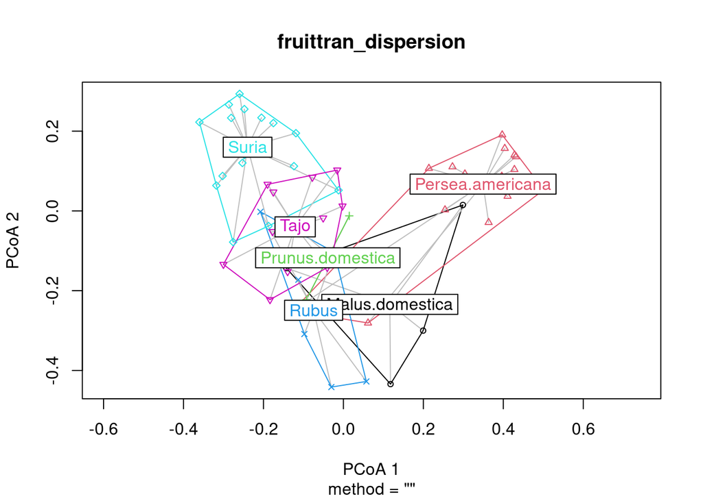

```r
# Calculate multivariate dispersions
fruittran_dispersion <- betadisper(t(sorensen_dist_q1),
    bichos_hier_df$Fruitcrop_transect)

plot(fruittran_dispersion)
```

```r
# test for differences in dispersion

anova(fruittran_dispersion)
```

```
## Analysis of Variance Table
##
## Response: Distances
##           Df  Sum Sq   Mean Sq F value Pr(>F)
## Groups     5 0.06049 0.0120981  1.2106 0.3176
## Residuals 51 0.50969 0.0099939
```

```r
# Permutation test for F
set.seed(231023)
permutest(fruittran_dispersion, pairwise = TRUE,
    permutations = 99)
```

```
##
## Permutation test for homogeneity of multivariate dispersions
## Permutation: free
## Number of permutations: 99
##
## Response: Distances
##           Df  Sum Sq   Mean Sq      F N.Perm Pr(>F)
## Groups     5 0.06049 0.0120981 1.2106     99    0.4
## Residuals 51 0.50969 0.0099939
##
## Pairwise comparisons:
## (Observed p-value below diagonal, permuted p-value above diagonal)
##                  Malus.domestica Persea.americana Prunus.domestica    Rubus
## Malus.domestica                          0.650000         0.040000 0.350000
## Persea.americana        0.503343                          0.180000 0.610000
## Prunus.domestica        0.036595         0.170350                  0.250000
## Rubus                   0.308204         0.625703         0.304851
## Suria                   0.086332         0.211510         0.278235 0.673945
## Tajo                    0.122748         0.583287         0.053807 0.860292
##                     Suria Tajo
## Malus.domestica  0.190000 0.25
## Persea.americana 0.230000 0.59
## Prunus.domestica 0.290000 0.06
## Rubus            0.680000 0.80
## Suria                     0.36
## Tajo             0.377397
```

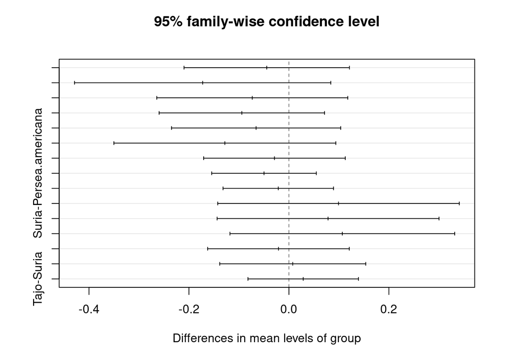

```r
## Tukey's Honest Significant Differences
fruittran_HSD <- TukeyHSD(fruittran_dispersion)
plot(fruittran_HSD)
```

> Perform a NMDS

```r
# run NMDS q0
set.seed(20102023)
values_NMDS_q0 <- metaMDS(as.dist(sorensen_dist_q0),
    k = 4, trymax = 500)
```

```
## *** Best solution repeated 4 times
```

```r
values_NMDS_q0$stress
```

```
## [1] 0.1206653
```

```r
stressplot(values_NMDS_q0)
```

[output not shown]

```r
# run NMDS q1
set.seed(20102023)
values_NMDS_q1 <- metaMDS(as.dist(sorensen_dist_q1),
    k = 4, trymax = 500)
```

```
## *** Best solution repeated 1 times
```

```r
values_NMDS_q1$stress
```

```
## [1] 0.1259136
```

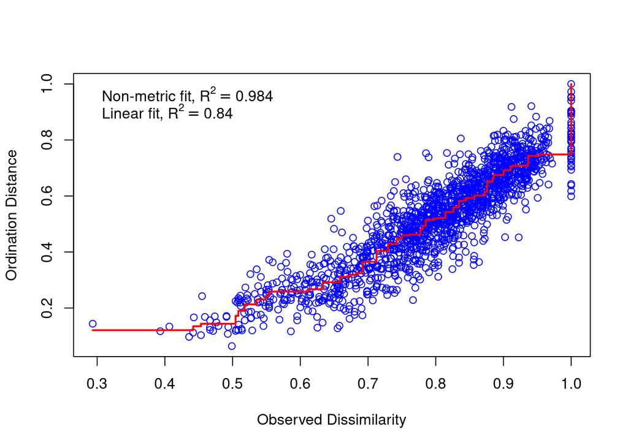

```r
stressplot(values_NMDS_q1)
```

```r
# run NMDS q2
set.seed(20102023)
values_NMDS_q2 <- metaMDS(as.dist(sorensen_dist_q2),
    k = 4, trymax = 500)
```

```
## *** Best solution repeated 4 times
```

```r
values_NMDS_q2$stress
```

```
## [1] 0.1206653
```

```r
stressplot(values_NMDS_q2)
```

[output not shown]

NMDS values for plot

```r
NMDS_scores_q0 <- data.frame(NMDS1 = values_NMDS_q0$point[,
    1], NMDS2 = values_NMDS_q0$point[, 2], NMDS3 = values_NMDS_q0$point[,
    3], NMDS4 = values_NMDS_q0$point[, 4], Group = as.factor(bichos_hier_df[,
    4]))

NMDS_scores_q0 <- NMDS_scores_q0 %>%
    mutate(Group = gsub("\\.", " ", Group))


NMDS_centroids_q0 = aggregate(NMDS_scores_q0[,
    c(1:2)], by = list(NMDS_scores_q0[, 5]), FUN = mean)

NMDS_scores_q0$Sample <- rownames(NMDS_scores_q0)

colnames(NMDS_centroids_q0) <- c("Group", "x_cen",
    "y_cen")

NMDS_scores_q0 <- merge(NMDS_scores_q0, NMDS_centroids_q0,
    by = "Group")


NMDS_scores_q1 <- data.frame(NMDS1 = values_NMDS_q1$point[,
    1], NMDS2 = values_NMDS_q1$point[, 2], NMDS3 = values_NMDS_q1$point[,
    3], NMDS4 = values_NMDS_q1$point[, 4], Group = as.factor(bichos_hier_df[,
    4]))

NMDS_scores_q1 <- NMDS_scores_q1 %>%
    mutate(Group = gsub("\\.", " ", Group))

NMDS_centroids_q1 = aggregate(NMDS_scores_q1[,
    c(1:2)], by = list(NMDS_scores_q1[, 5]), FUN = mean)

NMDS_scores_q1$Sample <- rownames(NMDS_scores_q1)

colnames(NMDS_centroids_q1) <- c("Group", "x_cen",
    "y_cen")

NMDS_scores_q1 <- merge(NMDS_scores_q1, NMDS_centroids_q1,
    by = "Group")

NMDS_scores_q2 <- data.frame(NMDS1 = values_NMDS_q2$point[,
    1], NMDS2 = values_NMDS_q2$point[, 2], NMDS3 = values_NMDS_q2$point[,
    3], NMDS4 = values_NMDS_q2$point[, 4], Group = as.factor(bichos_hier_df[,
    4]))

NMDS_scores_q2 <- NMDS_scores_q2 %>%
    mutate(Group = gsub("\\.", " ", Group))

NMDS_centroids_q2 = aggregate(NMDS_scores_q2[,
    c(1:2)], by = list(NMDS_scores_q2[, 5]), FUN = mean)


NMDS_scores_q2$Sample <- rownames(NMDS_scores_q2)

colnames(NMDS_centroids_q2) <- c("Group", "x_cen",
    "y_cen")

NMDS_scores_q2 <- merge(NMDS_scores_q2, NMDS_centroids_q2,
    by = "Group")
```

Plot NMDS results using incidence data

```r
head(NMDS_scores_q0)
```

```
##              Group      NMDS1       NMDS2       NMDS3       NMDS4
## 1  Malus domestica -0.1440770  0.12821583  0.11875611 -0.27433866
## 2  Malus domestica  0.2945085  0.42938285  0.32140208  0.03334253
## 3  Malus domestica  0.2848489  0.06365933 -0.22637676  0.14505870
## 4  Malus domestica  0.1093655  0.38316587  0.07251347 -0.08554794
## 5 Persea americana -0.1978455  0.36966785 -0.20438108 -0.21924583
## 6 Persea americana  0.4203648 -0.10472664 -0.01882055 -0.18308425
##                                  Sample     x_cen       y_cen
## 1   Cultivos_10_Malus.domestica_January 0.1361615  0.25110597
## 2      Cultivos_18_Malus.domestica_July 0.1361615  0.25110597
## 3 Cultivos_20_4_Persea.americana_August 0.1361615  0.25110597
## 4            Cultivos_24_Rubus_November 0.1361615  0.25110597
## 5  Cultivos_10_Persea.americana_January 0.3136813 -0.01420433
## 6   Cultivos_19_2_Persea.americana_July 0.3136813 -0.01420433
```

```r
nmds_q0_fruitcrop_plot <- ggplot(NMDS_scores_q0,
    aes(x = NMDS1, y = NMDS2, colour = Group,
        fill = Group)) + geom_point(size = 2) +
    crop_transect_color + crop_transect_fill +
    geom_point(data = NMDS_scores_q0, aes(x = x_cen,
        y = y_cen, fill = Group), shape = 21,
        colour = "black", size = 5, show.legend = FALSE) +
    ord_theme + theme(legend.text = element_text(face = "italic",
    size = 10), legend.title = element_text(size = 12))

nmds_q1_fruitcrop_plot <- ggplot(NMDS_scores_q1,
    aes(x = NMDS1, y = NMDS2, colour = Group,
        fill = Group)) + geom_point(size = 2) +
    crop_transect_color + crop_transect_fill +
    geom_point(data = NMDS_scores_q1, aes(x = x_cen,
        y = y_cen, fill = Group), shape = 21,
        colour = "black", size = 5, show.legend = FALSE) +
    ord_theme + theme(legend.text = element_text(face = "italic",
    size = 10), legend.title = element_text(size = 12))

nmds_q2_fruitcrop_plot <- ggplot(NMDS_scores_q2,
    aes(x = NMDS1, y = NMDS2, colour = Group,
        fill = Group)) + geom_point(size = 2) +
    crop_transect_color + crop_transect_fill +
    geom_point(data = NMDS_scores_q2, aes(x = x_cen,
        y = y_cen, fill = Group), shape = 21,
        colour = "black", size = 5, show.legend = FALSE) +
    ord_theme + theme(legend.text = element_text(face = "italic",
    size = 10), legend.title = element_text(size = 12))


# ellipses for q0 plot
NMDS_scores_q0_noPrune <- NMDS_scores_q0 %>%
    filter(Group != "Prunus domestica")

# data for ellipse, in this case using the
# management factor
df_ell_q0 <- data.frame()  #sets up a data frame before running the function.
for (g in levels(as.factor(NMDS_scores_q0_noPrune$Group))) {
    df_ell_q0 <- rbind(df_ell_q0, cbind(as.data.frame(with(NMDS_scores_q0_noPrune[NMDS_scores_q0_noPrune$Group ==
        g, ], veganCovEllipse(cov.wt(cbind(NMDS1,
        NMDS2), wt = rep(1/length(NMDS1), length(NMDS1)))$cov,
        center = c(mean(NMDS1), mean(NMDS2))))),
        Group = g))
}

# data for labelling the ellipse
NMDS_mean_q0 = aggregate(NMDS_scores_q0_noPrune[,
    c("NMDS1", "NMDS2")], list(group = NMDS_scores_q0_noPrune$Group),
    mean)


# ellipses for q1 plot
NMDS_scores_q1_noPrune <- NMDS_scores_q1 %>%
    filter(Group != "Prunus domestica")

# data for ellipse, in this case using the
# management factor
df_ell_q1 <- data.frame()  #sets up a data frame before running the function.
for (g in levels(as.factor(NMDS_scores_q1_noPrune$Group))) {
    df_ell_q1 <- rbind(df_ell_q1, cbind(as.data.frame(with(NMDS_scores_q1_noPrune[NMDS_scores_q1_noPrune$Group ==
        g, ], veganCovEllipse(cov.wt(cbind(NMDS1,
        NMDS2), wt = rep(1/length(NMDS1), length(NMDS1)))$cov,
        center = c(mean(NMDS1), mean(NMDS2))))),
        Group = g))
}

# data for labelling the ellipse
NMDS_mean_q1 = aggregate(NMDS_scores_q1_noPrune[,
    c("NMDS1", "NMDS2")], list(group = NMDS_scores_q1_noPrune$Group),
    mean)


# ellipses for q2 plot
NMDS_scores_q2_noPrune <- NMDS_scores_q2 %>%
    filter(Group != "Prunus domestica")

# data for ellipse, in this case using the
# management factor
df_ell_q2 <- data.frame()  #sets up a data frame before running the function.
for (g in levels(as.factor(NMDS_scores_q2_noPrune$Group))) {
    df_ell_q2 <- rbind(df_ell_q2, cbind(as.data.frame(with(NMDS_scores_q2_noPrune[NMDS_scores_q2_noPrune$Group ==
        g, ], veganCovEllipse(cov.wt(cbind(NMDS1,
        NMDS2), wt = rep(1/length(NMDS1), length(NMDS1)))$cov,
        center = c(mean(NMDS1), mean(NMDS2))))),
        Group = g))
}

# data for labelling the ellipse
NMDS_mean_q2 = aggregate(NMDS_scores_q2_noPrune[,
    c("NMDS1", "NMDS2")], list(group = NMDS_scores_q2_noPrune$Group),
    mean)

nmds_q0_fruitcrop_plot <- nmds_q0_fruitcrop_plot +
    geom_path(data = df_ell_q0, aes(x = NMDS1,
        y = NMDS2, group = Group))

nmds_q1_fruitcrop_plot <- nmds_q1_fruitcrop_plot +
    geom_path(data = df_ell_q1, aes(x = NMDS1,
        y = NMDS2, group = Group))

nmds_q2_fruitcrop_plot <- nmds_q2_fruitcrop_plot +
    geom_path(data = df_ell_q2, aes(x = NMDS1,
        y = NMDS2, group = Group))

nmds_fruitcrop_plot <- ggarrange(nmds_q0_fruitcrop_plot,
    nmds_q1_fruitcrop_plot, nmds_q2_fruitcrop_plot,
    nrow = 1, labels = c("a.", "b.", "c."), font.label = c(size = 16),
    common.legend = TRUE, legend = "bottom")


png(paste0(outputDir, "/Figures/NMDS_fruitcrop_transect.png"),
    width = 3000, height = 1500, res = 300)
nmds_fruitcrop_plot
dev.off()
```

Combine NMDS plots

```r
NMDS_combined <- ggarrange(nmds_q1_proj_plot,
    nmds_q1_fruitcrop_plot, nrow = 1, labels = c("a.",
        "b."), font.label = list(size = 20, face = "bold",
        family = "Helvetica", size = 16), common.legend = FALSE,
    legend = "right")


png(paste0(outputDir, "/Figures/Figure2.png"),
    width = 3000, height = 1200, res = 300)
NMDS_combined
dev.off()
```

````
# notes


```r
# to get the polygons for a grouping factor
# Group_Tajo <-
# NMDS_scores[NMDS_scores$Group == 'Tajo',
# ][chull(NMDS_scores[NMDS_scores$Group ==
# 'Tajo', c('NMDS1', 'NMDS2')]),]

# bind hull data into object to add polygons
# to ggplot

# geom_polygon(data = hull_data, aes(x =
# NMDS1, y = NMDS2), alpha = 0.5) +
````

## Session Info

```r
sessioninfo::session_info() %>%
    details::details(summary = "Current session info",
        open = FALSE)
```

**Current session info**

```r
─ Session info ───────────────────────────────────────────────────────────────
 setting  value
 version  R version 4.3.3 (2024-02-29)
 os       Linux Mint 21.3
 system   x86_64, linux-gnu
 ui       X11
 language en_US
 collate  en_IN.UTF-8
 ctype    en_IN.UTF-8
 tz       Europe/Berlin
 date     2024-05-02
 pandoc   3.1.13 @ /usr/local/bin/ (via rmarkdown)

─ Packages ───────────────────────────────────────────────────────────────────
 package           * version    date (UTC) lib source
 abind               1.4-5      2016-07-21 [1] CRAN (R 4.3.0)
 ape                 5.7-1      2023-03-13 [1] CRAN (R 4.3.0)
 backports           1.4.1      2021-12-13 [1] CRAN (R 4.3.0)
 base64enc           0.1-3      2015-07-28 [1] CRAN (R 4.3.0)
 broom               1.0.5      2023-06-09 [1] CRAN (R 4.3.1)
 bslib               0.5.1      2023-08-11 [1] CRAN (R 4.3.1)
 cachem              1.0.8      2023-05-01 [1] CRAN (R 4.3.0)
 car                 3.1-2      2023-03-30 [1] CRAN (R 4.3.0)
 carData             3.0-5      2022-01-06 [1] CRAN (R 4.3.0)
 checkmate           2.2.0      2023-04-27 [1] CRAN (R 4.3.0)
 cli                 3.6.2      2023-12-11 [1] CRAN (R 4.3.3)
 clipr               0.8.0      2022-02-22 [1] CRAN (R 4.3.0)
 cluster             2.1.4      2022-08-22 [1] CRAN (R 4.3.0)
 clusterGeneration   1.3.8      2023-08-16 [1] CRAN (R 4.3.1)
 coda                0.19-4     2020-09-30 [1] CRAN (R 4.3.1)
 codetools           0.2-19     2023-02-01 [1] CRAN (R 4.3.0)
 colorspace          2.1-0      2023-01-23 [1] CRAN (R 4.3.0)
 combinat            0.0-8      2012-10-29 [1] CRAN (R 4.3.1)
 corpcor             1.6.10     2021-09-16 [1] CRAN (R 4.3.1)
 cowplot             1.1.1      2020-12-30 [1] CRAN (R 4.3.0)
 data.table          1.14.8     2023-02-17 [1] CRAN (R 4.3.0)
 desc                1.4.2      2022-09-08 [1] CRAN (R 4.3.0)
 deSolve             1.38       2023-09-05 [1] CRAN (R 4.3.1)
 details           * 0.3.0      2022-03-27 [1] CRAN (R 4.3.0)
 digest              0.6.35     2024-03-11 [1] CRAN (R 4.3.3)
 doParallel          1.0.17     2022-02-07 [1] CRAN (R 4.3.0)
 dplyr             * 1.1.4      2023-11-17 [1] CRAN (R 4.3.3)
 evaluate            0.23       2023-11-01 [1] CRAN (R 4.3.2)
 expm                0.999-7    2023-01-09 [1] CRAN (R 4.3.1)
 fansi               1.0.6      2023-12-08 [1] CRAN (R 4.3.3)
 farver              2.1.1      2022-07-06 [1] CRAN (R 4.3.0)
 fastmap             1.1.1      2023-02-24 [1] CRAN (R 4.3.0)
 fastmatch           1.1-4      2023-08-18 [1] CRAN (R 4.3.1)
 fdrtool             1.2.17     2021-11-13 [1] CRAN (R 4.3.1)
 forcats           * 1.0.0      2023-01-29 [1] CRAN (R 4.3.0)
 foreach             1.5.2      2022-02-02 [1] CRAN (R 4.3.0)
 foreign             0.8-84     2022-12-06 [1] CRAN (R 4.3.0)
 formatR             1.14       2023-01-17 [1] CRAN (R 4.3.0)
 Formula             1.2-5      2023-02-24 [1] CRAN (R 4.3.0)
 FSA                 0.9.5      2023-08-26 [1] CRAN (R 4.3.1)
 geiger              2.0.11     2023-04-03 [1] CRAN (R 4.3.1)
 generics            0.1.3      2022-07-05 [1] CRAN (R 4.3.0)
 ggplot2           * 3.5.1      2024-04-23 [1] CRAN (R 4.3.3)
 ggpubr            * 0.6.0      2023-02-10 [1] CRAN (R 4.3.0)
 ggrepel             0.9.4      2023-10-13 [1] CRAN (R 4.3.1)
 ggsignif            0.6.4      2022-10-13 [1] CRAN (R 4.3.0)
 glasso              1.11       2019-10-01 [1] CRAN (R 4.3.1)
 glue                1.7.0      2024-01-09 [1] CRAN (R 4.3.3)
 gridExtra           2.3        2017-09-09 [1] CRAN (R 4.3.0)
 gtable              0.3.5      2024-04-22 [1] CRAN (R 4.3.3)
 gtools              3.9.4      2022-11-27 [1] CRAN (R 4.3.1)
 highr               0.10       2022-12-22 [1] CRAN (R 4.3.0)
 hilldiv           * 1.5.3      2023-10-13 [1] Github (anttonalberdi/hilldiv@551c284)
 Hmisc               5.1-1      2023-09-12 [1] CRAN (R 4.3.1)
 hms                 1.1.3      2023-03-21 [1] CRAN (R 4.3.0)
 htmlTable           2.4.1      2022-07-07 [1] CRAN (R 4.3.0)
 htmltools           0.5.7      2023-11-03 [1] CRAN (R 4.3.2)
 htmlwidgets         1.6.2      2023-03-17 [1] CRAN (R 4.3.0)
 httr                1.4.7      2023-08-15 [1] CRAN (R 4.3.2)
 igraph              1.5.1      2023-08-10 [1] CRAN (R 4.3.1)
 iNEXT             * 3.0.0      2022-08-29 [1] CRAN (R 4.3.1)
 iterators           1.0.14     2022-02-05 [1] CRAN (R 4.3.0)
 jpeg                0.1-10     2022-11-29 [1] CRAN (R 4.3.0)
 jquerylib           0.1.4      2021-04-26 [1] CRAN (R 4.3.0)
 jsonlite            1.8.7      2023-06-29 [1] CRAN (R 4.3.1)
 kableExtra        * 1.3.4.9000 2023-06-03 [1] Github (haozhu233/kableExtra@292f607)
 knitr             * 1.45       2023-10-30 [1] CRAN (R 4.3.2)
 labeling            0.4.3      2023-08-29 [1] CRAN (R 4.3.1)
 lattice           * 0.21-8     2023-04-05 [1] CRAN (R 4.3.0)
 lavaan              0.6-16     2023-07-19 [1] CRAN (R 4.3.1)
 lifecycle           1.0.4      2023-11-07 [1] CRAN (R 4.3.2)
 lubridate         * 1.9.2      2023-02-10 [1] CRAN (R 4.3.0)
 magrittr          * 2.0.3      2022-03-30 [1] CRAN (R 4.3.0)
 maps                3.4.1      2022-10-30 [1] CRAN (R 4.3.0)
 MASS                7.3-60     2023-05-04 [1] CRAN (R 4.3.0)
 Matrix              1.5-4.1    2023-05-18 [1] CRAN (R 4.3.0)
 mgcv                1.8-42     2023-03-02 [1] CRAN (R 4.3.0)
 mnormt              2.1.1      2022-09-26 [1] CRAN (R 4.3.1)
 munsell             0.5.1      2024-04-01 [1] CRAN (R 4.3.3)
 mvtnorm             1.2-3      2023-08-25 [1] CRAN (R 4.3.1)
 nlme                3.1-162    2023-01-31 [1] CRAN (R 4.3.0)
 nnet                7.3-19     2023-05-03 [1] CRAN (R 4.3.0)
 numDeriv            2016.8-1.1 2019-06-06 [1] CRAN (R 4.3.0)
 optimParallel       1.0-2      2021-02-11 [1] CRAN (R 4.3.1)
 pbapply             1.7-2      2023-06-27 [1] CRAN (R 4.3.1)
 pbivnorm            0.6.0      2015-01-23 [1] CRAN (R 4.3.1)
 permute           * 0.9-7      2022-01-27 [1] CRAN (R 4.3.0)
 phangorn            2.11.1     2023-01-23 [1] CRAN (R 4.3.0)
 phytools            1.9-16     2023-07-14 [1] CRAN (R 4.3.1)
 pillar              1.9.0      2023-03-22 [1] CRAN (R 4.3.0)
 pkgconfig           2.0.3      2019-09-22 [1] CRAN (R 4.3.0)
 plotrix             3.8-2      2021-09-08 [1] CRAN (R 4.3.1)
 plyr                1.8.9      2023-10-02 [1] CRAN (R 4.3.1)
 png                 0.1-8      2022-11-29 [1] CRAN (R 4.3.2)
 psych               2.3.9      2023-09-26 [1] CRAN (R 4.3.1)
 purrr             * 1.0.2      2023-08-10 [1] CRAN (R 4.3.1)
 qgraph              1.9.5      2023-05-16 [1] CRAN (R 4.3.1)
 quadprog            1.5-8      2019-11-20 [1] CRAN (R 4.3.0)
 R6                  2.5.1      2021-08-19 [1] CRAN (R 4.3.0)
 RColorBrewer        1.1-3      2022-04-03 [1] CRAN (R 4.3.0)
 Rcpp                1.0.12     2024-01-09 [1] CRAN (R 4.3.3)
 readr             * 2.1.4      2023-02-10 [1] CRAN (R 4.3.0)
 reshape2            1.4.4      2020-04-09 [1] CRAN (R 4.3.0)
 rlang               1.1.3      2024-01-10 [1] CRAN (R 4.3.3)
 rmarkdown           2.25       2023-09-18 [1] CRAN (R 4.3.1)
 rpart               4.1.19     2022-10-21 [1] CRAN (R 4.3.0)
 rprojroot           2.0.3      2022-04-02 [1] CRAN (R 4.3.0)
 rstatix             0.7.2      2023-02-01 [1] CRAN (R 4.3.0)
 rstudioapi          0.15.0     2023-07-07 [1] CRAN (R 4.3.1)
 rvest               1.0.3      2022-08-19 [1] CRAN (R 4.3.0)
 sass                0.4.7      2023-07-15 [1] CRAN (R 4.3.1)
 scales              1.3.0      2023-11-28 [1] CRAN (R 4.3.3)
 scatterplot3d       0.3-44     2023-05-05 [1] CRAN (R 4.3.1)
 sessioninfo         1.2.2      2021-12-06 [1] CRAN (R 4.3.0)
 stringi             1.8.3      2023-12-11 [1] CRAN (R 4.3.3)
 stringr           * 1.5.1      2023-11-14 [1] CRAN (R 4.3.3)
 subplex             1.8        2022-04-12 [1] CRAN (R 4.3.1)
 svglite             2.1.1      2023-01-10 [1] CRAN (R 4.3.0)
 systemfonts         1.0.5      2023-10-09 [1] CRAN (R 4.3.1)
 tibble            * 3.2.1      2023-03-20 [1] CRAN (R 4.3.0)
 tidyr             * 1.3.0      2023-01-24 [1] CRAN (R 4.3.0)
 tidyselect          1.2.1      2024-03-11 [1] CRAN (R 4.3.3)
 tidyverse         * 2.0.0      2023-02-22 [1] CRAN (R 4.3.0)
 timechange          0.2.0      2023-01-11 [1] CRAN (R 4.3.0)
 tzdb                0.4.0      2023-05-12 [1] CRAN (R 4.3.0)
 utf8                1.2.4      2023-10-22 [1] CRAN (R 4.3.1)
 vctrs               0.6.5      2023-12-01 [1] CRAN (R 4.3.3)
 vegan             * 2.6-4      2022-10-11 [1] CRAN (R 4.3.0)
 viridisLite         0.4.2      2023-05-02 [1] CRAN (R 4.3.0)
 webshot             0.5.4      2022-09-26 [1] CRAN (R 4.3.0)
 withr               3.0.0      2024-01-16 [1] CRAN (R 4.3.3)
 xfun                0.43       2024-03-25 [1] CRAN (R 4.3.3)
 xml2                1.3.6      2023-12-04 [1] CRAN (R 4.3.3)
 yaml                2.3.7      2023-01-23 [1] CRAN (R 4.3.0)

 [1] /home/kari/R/x86_64-pc-linux-gnu-library/4.3
 [2] /usr/local/lib/R/site-library
 [3] /usr/lib/R/site-library
 [4] /usr/lib/R/library

──────────────────────────────────────────────────────────────────────────────
```